# The Metagenome of Black Band Disease

Akshay Chaitanya Talachintala

2026-11-06

# Background

## Black band disease: a complex microbial infection

Black band disease (BBD) is a coral disease that shows a dark moving microbial mat. This mat moves across coral tissue leaving bare skeleton behind. Unlike infections caused by a pathogen Black band disease involves many different microbes that together break down the coral tissue. The disease can remove amounts of tissue and in the worst cases kill the coral colony as shown by studies such as Zimmer et al. (2014). Sato et al. (2016).

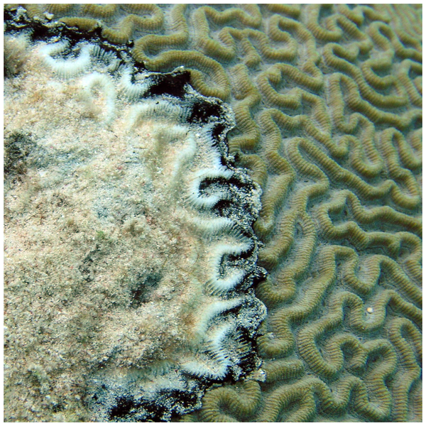

Black band disease affecting *Diploria strigosa* in Curaçao. Photograph by Abigael Brownell; Zimmer et al. (2014), CC BY 4.0.

## Microbial interactions within the disease mat

The BBD microbial mat usually contains cyanobacteria, sulfate‑reducing bacteria sulfur‑oxidising bacteria and other heterotrophic microbes. Cyanobacteria, those from the genus *Roseofilum* play a key photosynthetic role in this community.. The mat also supports microbes with different metabolic needs creating a very organized microbial environment (Sato et al., 2016).

Photosynthesis can raise oxygen levels in the illuminated layers while microbial respiration pulls oxygen out. As a result steep oxygen gradients form inside the mat with deeper parts becoming oxygen‑free or anoxic. These conditions shift with light and switch between day and night (Carlton & Richardson 1995).

In oxygen‑free zones sulfate‑reducing microbes can produce hydrogen sulfide. The mix of oxygen and high sulfide near the coral‑mat border stresses the tissue and drives disease progression (Glas et al., 2012).

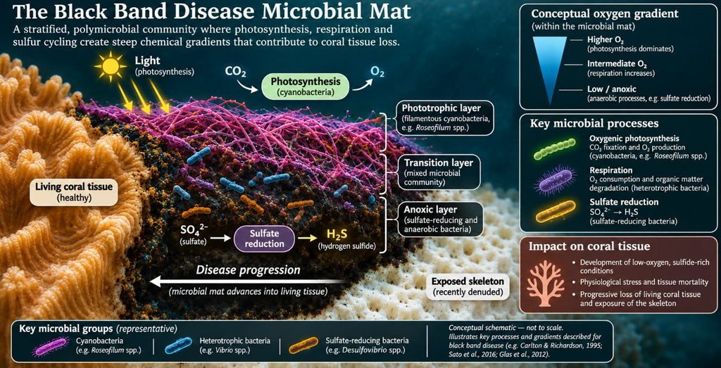

Conceptual representation of the black band disease microbial mat, illustrating photosynthesis, oxygen gradients, sulfate reduction and coral tissue loss. Based on Carlton and Richardson (1995), Glas et al. (2012) and Sato et al. (2016). Not to scale.

## Why investigate the genomes?

Although many researchers have explored the diversity and biogeochemical traits of BBD simply finding microbes does not show what each one can do or how it helps the disease.

Genome‑resolved metagenomics gives a chance to look at these questions by piecing together DNA from the environment. After we assemble the DNA and separate it into genomes we can check how complete each genome is, label its group and search for genes that link to specific metabolic tasks.

Long‑read sequencing can help finish genome regions that short reads miss. Mistakes in assembly missing pieces and uncertainty about what genes actually do can still be problems.

Crucially spotting a gene or a predicted pathway tells us what a microbe might be able to do. It does not prove that the gene is active or that the microbe is producing the compound in real life.

## Study aim and objectives

*Beneath the Band* looks at genome diversity and predicted metabolic functions in black band disease‑related metagenomic data from *Acropora hyacinthus* taken at Orpheus Island, Queensland, Australia.

**Research question:** What can genome‑resolved analysis reveal about the microbial diversity and potential metabolic functions linked to coral black band disease?

The study aims to:

- Assemble metagenomic sequences and reconstruct candidate microbial genomes.
- Evaluate how complete each genome bin is and how much contamination it has.
- Identify the main bacterial lineages shown by recovered genomes.
- Characterise the predicted protein‑coding genes and enzyme annotations.
- Investigate genomic clues for photosynthesis. Sulfur‑related metabolic pathways.

These analyses give a framework for understanding the potential of the recovered community and, for comparing it with earlier black band disease studies.

# Results

## 3.1 Assembly of metagenomes

Using Flye the metagenomic reads from the black band disease were assembled into 7,979 contigs covering a total of about 66.69 Mbp. The largest contig reached 4.71 Mbp in length. The assembly N50 was 12,985 bp (Table 1).

Table 1. Summary statistics for the Flye metagenomic assembly.

| Assembly metric | Value |
| --- | --- |
| Number of contigs | 7,979 |
| Total assembly length | 66,690,645 bp (66.69 Mbp) |
| Largest contig | 4,706,700 bp (4.71 Mbp) |
| Contig N50 | 12,985 bp (12.99 kbp) |

The relatively low N50 value and the high number of contigs indicate that a large part of the metagenomic assembly remains broken into smaller pieces despite the presence of a contig that is several megabases long. Still the continuity of contigs does not reflect the quality of the reconstructed microbial genomes. To evaluate the completeness and contamination levels of genome bins CheckM was used, as described in Section 3.2.

## 3.2 Genome recovery and quality

Two candidate genomes, `contig_134` and `metabat.45` showed high estimated completeness, 97.62% and 97.56% respectively and had relatively low contamination (Table 2). In comparison several other candidate genomes had lower completeness even though they showed little or no estimated contamination.

Table 2. CheckM quality estimates for five selected genome candidates.

| Genome candidate | Completeness (%) | Contamination (%) |
| --- | --- | --- |
| contig_134 | 97.62 | 1.64 |
| metabat.45 | 97.56 | 0.67 |
| metabat.3 | 34.48 | 0.00 |
| metabat.18 | 30.28 | 0.00 |
| metabat.9 | 28.18 | 0.13 |

### Genome quality visualisation

The completeness and contamination estimates for all sixteen selected candidate genomes are shown in Figure 3. This comparison lets complete candidate genomes be distinguished from more fragmented recoveries.

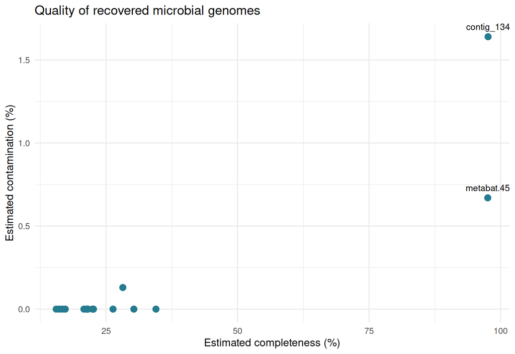

Figure 3. Estimated completeness and contamination of 16 selected genome candidates based on CheckM analysis.

The CheckM results reveal variation, in genome recovery. Although `contig_134` and `metabat.45` were recovered with estimated completeness, other selected candidate genomes represent considerably less complete genomic reconstructions.

## 3.3 Taxonomic composition of genomes

Used GTDB‑Tk to classify the 16 chosen genome candidates in order to explore the microbial diversity that appears in the black band disease (BBD) metagenome. The results showed lineages at many taxonomic levels from species‑level labels all the way up to higher ranks that could not be resolved (see Table.3).

The recovered genomes are members of Bacteroidota and Campylobacterota. The complete candidate `contig_134` was placed in Bacteroidota within the family Bernardetiaceae and the genus UBA2561. In Campylobacterota two candidates, `metabat.10` and `metabat.18` belong to the genus *Halarcobacter* while `metabat.22` falls into *Poseidonibacter*. These assignments show that several different bacterial lineages are part of the community that causes the disease.

### Taxonomic assignments of genome candidates

Table 3. GTDB-Tk taxonomic assignments of the 16 selected genome candidates.

|  | Genome candidate | Phylum | Genus | Species |
| --- | --- | --- | --- | --- |
| 1 | contig_134 | Bacteroidota | UBA2561 | UBA2561 sp002340355 |
| 15 | metabat.76 | Bacteroidota | DT-34 | Unclassified |
| 2 | metabat.10 | Campylobacterota | Halarcobacter | Unclassified |
| 3 | metabat.18 | Campylobacterota | Halarcobacter | Unclassified |
| 4 | metabat.22 | Campylobacterota | Poseidonibacter | Unclassified |
| 5 | metabat.3 | Campylobacterota | Halarcobacter | Unclassified |
| 14 | metabat.71 | Campylobacterota | Sulfurospirillum_A | Unclassified |
| 9 | metabat.45 | Cyanobacteria | Roseofilum | Roseofilum reptotaenium_A |
| 8 | metabat.37 | Desulfobacterota | Unclassified | Unclassified |
| 10 | metabat.50 | Desulfobacterota | Unclassified | Unclassified |
| 16 | metabat.9 | Desulfobacterota | Unclassified | Unclassified |
| 11 | metabat.56 | Desulfobacterota_I | Maridesulfovibrio | Unclassified |
| 6 | metabat.32 | Firmicutes_A | Unclassified | Unclassified |
| 7 | metabat.36 | Firmicutes_A | Unclassified | Unclassified |
| 12 | metabat.60 | Firmicutes_A | JABXKX01 | Unclassified |
| 13 | metabat.70 | Unclassified | Unclassified | Unclassified |

### Distribution of recovered lineages

We examined the phylum‑level distribution of the selected genome candidates (Figure.4). This gives a snapshot of the bacterial lineages that appear in the reconstructed genomes although the number of candidates does not equal the actual bacterial abundance in the original sample.

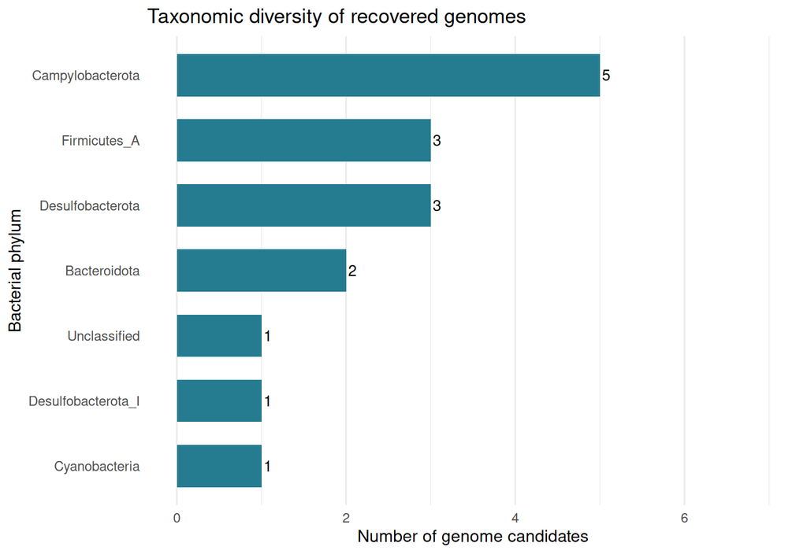

Figure 4. Distribution of the 16 selected genome candidates across bacterial phyla based on GTDB-Tk classifications.

### resolution and biological relevance

Across the 16 genome candidates, GTDB-Tk identified 7 distinct phylum-level categories. 10 candidates received genus-level assignments, while 2 were classified to species level. The remaining candidates were resolved only to broader taxonomic ranks.

Cyanobacterial lineages were represented among the recovered genomes, including metabat.45. These candidates are particularly relevant to investigating the photosynthetic component of the BBD microbial mat.

Members of Desulfobacterota were also recovered, including metabat.37, metabat.50, metabat.56, metabat.9. Their taxonomic placement makes them relevant candidates for subsequent investigation of sulfur-related metabolic potential.

Overall the GTDB‑Tk classifications show that the selected genome candidates form a taxonomically diverse collection of bacteria that are associated with the BBD sample. These genome candidates are diverse. Differences in genome completeness and taxonomic resolution create uncertainty when interpreting assignments for genome candidates especially for highly incomplete bins. In addition taxonomic identity alone does not confirm activity, sulfate reduction or a direct role, in disease progression. Functional gene annotation and metabolic pathway reconstruction were therefore used to examine the biological capabilities of these bacteria.

## 3.4 Functional gene annotation

Functional gene annotation of the 16 selected genome candidates was carried out with Prokka to identify predicted protein‑coding sequences (CDS) and to give them gene functions. The functional gene annotation covered proteins that had known functions, proteins that had no specific functional assignments and genes that were linked to Enzyme Commission (EC) numbers.

To look at differences in annotation coverage, among the genomes the total numbers of predicted CDS, hypothetical proteins and EC‑annotated CDS were counted for each candidate (Table.4).

### Summary of predicted protein‑coding gene

Table 4. Prokka functional annotation summary for the 16 selected genome candidates.

|  | Genome candidate | Total CDS | Hypothetical proteins | Hypothetical (%) | CDS with EC numbers |
| --- | --- | --- | --- | --- | --- |
| 9 | metabat.45 | 5496 | 3329 | 60.6 | 1385 |
| 1 | contig_134 | 3913 | 2489 | 63.6 | 920 |
| 12 | metabat.60 | 2178 | 1379 | 63.3 | 478 |
| 14 | metabat.71 | 1009 | 539 | 53.4 | 282 |
| 3 | metabat.18 | 949 | 534 | 56.3 | 248 |
| 5 | metabat.3 | 895 | 413 | 46.1 | 271 |
| 16 | metabat.9 | 731 | 334 | 45.7 | 227 |
| 4 | metabat.22 | 667 | 414 | 62.1 | 149 |
| 8 | metabat.37 | 634 | 324 | 51.1 | 176 |
| 10 | metabat.50 | 582 | 281 | 48.3 | 167 |
| 11 | metabat.56 | 494 | 256 | 51.8 | 147 |
| 2 | metabat.10 | 437 | 215 | 49.2 | 112 |
| 15 | metabat.76 | 417 | 248 | 59.5 | 103 |
| 6 | metabat.32 | 398 | 160 | 40.2 | 142 |
| 13 | metabat.70 | 228 | 140 | 61.4 | 63 |
| 7 | metabat.36 | 223 | 81 | 36.3 | 80 |

### Distribution of hypothetical proteins

The share of predicted coding sequences that were given a functional description changed from genome to genome. Figure 5 shows a comparison, between coding sequences annotated as proteins and coding sequences annotated with other functional descriptions giving a clear overview of how many coding sequences were annotated in each genome.

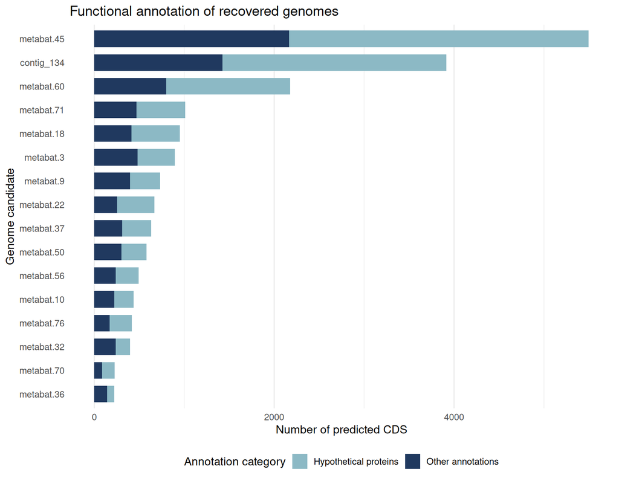

Figure 5. Predicted protein-coding sequences classified as hypothetical proteins or other functional annotations across the 16 genome candidates.

### Annotation coverage and enzyme assignments

Across the 16 selected genome candidates, Prokka predicted 19,251 protein-coding sequences. Of these, 11,136 (57.8%) were annotated as hypothetical proteins, while 4,950 CDS received EC-number assignments.

The genome candidate `metabat.45` contained 5,496 predicted CDS, including 3,329 hypothetical proteins (60.6%). This indicates that a substantial proportion of its predicted protein-coding genes could not be assigned specific functions through Prokka.

The presence of EC-number assignments gives us a starting point for exploring enzyme-driven metabolic processes.. It’s important to remember that functional annotation is based on sequence similarity and reference databases not on direct lab tests showing enzyme activity. Also if the genome recovery is not complete some genes and metabolic pathways may be missing in the less complete microbial candidates flagged by CheckM.

These annotated gene sets were then used in MinPath to reconstruct metabolic pathways. This helped us explore photosynthetic functions and sulfur-related activities, in the BBD microbial community.

## 3.5 Metabolic pathway reconstruction

Metabolic pathway reconstruction was carried out with MinPath to explore the functional capabilities of the recovered microbial genomes. Enzyme Commission (EC) annotations produced by Prokka were employed to spot candidate metabolic pathways those linked to photosynthesis and sulfur-associated processes that are important for black band disease (BBD).

MinPath gives two pieces of information: the count of enzyme families that belong to a pathway and whether that pathway remains in the reconstruction. By looking at both pieces metabolic pathway reconstruction can separate pathway predictions that have strong support, from those that only have one or a few enzyme families and are therefore weaker.

### Photosynthetic and sulfur-associated pathways

Table 5. MinPath evidence for photosynthesis light reactions (PWY-101) and tetrathionate reduction (PWY-5360) among selected genome candidates.

[output not shown]

Photosynthesis light reactions (PWY-101) were found in four genome candidates as shown in Table 5. The best evidence came from `metabat.45` where all four enzyme families that belong to the reference pathway were seen and MinPath chose this pathway. By contrast `metabat.32` was chosen even though it had one of the four enzyme families. `Contig_134` and `metabat.50` also had one of the four families but MinPath did not choose them.

The tetrathionate reduction superpathway (PWY-5360) was found in `metabat.18` where one of the three enzyme families was seen.. Minpath did not pick this pathway showing that the evidence was not enough to add it to the simplest reconstruction.

### Visualisation of metabolic pathway evidence

Figure 6 shows how many enzyme families were detected for the two pathways, in the genome candidates where they were reported. This picture gives a view of predicted metabolic potential, not the activity that has been measured in the lab.

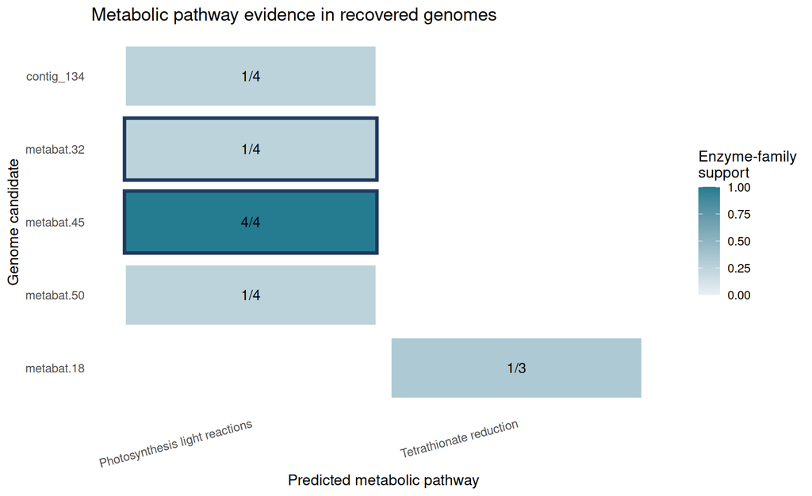

Figure 6. Enzyme-family support for photosynthesis light reactions (PWY-101) and tetrathionate reduction (PWY-5360) among recovered genome candidates. Labels indicate detected/reference enzyme families; outlined tiles indicate pathways selected by MinPath.

# Discussion

## 4.1 Metagenome assembly and genome recovery

The genome-resolved analysis of the black band disease (BBD) microbial community showed differences in how continuous the assembly was and how many genomes we could recover. The Flye assembly produced 7,979 contigs that together cover 66.69.Mbp. The low N50 value of 12,985.bp means the metagenome is still very broken into pieces. Still we were able to recover one contig that’s 4.71.Mbp long and two genome candidates that are about 97.6.% complete. This proves that we can pull out continuous genomic sequences from the long‑read data.

The different completeness scores of the 16 chosen candidates show a problem with metagenomic assembly. `Contig_134`. Metabat.45` are highly complete and have little contamination but many other candidates hold much less of their expected genome. These differences could come from sequencing coverage, how complex the community is, the nature of the genomes themselves or how well the assembly and binning tools work. The data we have now do not tell us which of these reasons is the cause.

Genome completeness matters a lot when we try to understand metabolism. If a gene or pathway is missing from a genome that does not automatically mean that the organism that owns that genome does not have that ability. Therefore we can trust conclusions from highly complete candidates more but we must be careful when a bin is incomplete and shows missing genes.

## 4.2 Microbial diversity and the significance of Roseofilum

The GTDB‑Tk classifications showed different bacterial lineages in the BBD metagenome we recovered which matches the idea that this disease involves many microbes. The complete candidate `contig_134` belongs to Bacteroidota while other candidates belong to Campylobacterota and include the genera *Halarcobacter* and *Poseidonibacter*. These results mean that the sample holds genomes from groups that are quite different from each other.

A key discovery was the recovery of `metabat.45` which GTDB‑Tk classifies as *Roseofilum reptotaenium_A*. This candidate is 97.56.% complete and has only 0.67.% contamination giving us a fairly complete genome of a cyanobacterium that is closely linked to BBD.

This result is very relevant to the study by Sato et al. (2017) Which found that the cyanobacterial bin called Cya2 is *Roseofilum reptotaenium* based on 16S data. The match between the *Roseofilum* genomes we recovered and the ones in that study shows how important this genus is in BBD communities. Still the GTDB label *R. Reptotaenium_A* is not automatically the same as the species name in the paper unless we compare the genomes directly.

Other bacterial lineages we found might show the ecological interactions inside the disease mat. However just knowing the taxonomy does not tell us whether these organisms help the disease get worse take part in metabolic tasks or simply live in the surrounding community.

## 4.3 Photosynthetic potential and microbial interactions

When we annotated functions and rebuilt pathways we found proof that the cyanobacterial genome is biologically important. In `metabat.45` the tool MinPath found all four enzyme families that belong to the photosynthesis light‑reaction pathway (PWY‑101). That pathway stayed in the reconstruction. This was the evidence for photosynthesis among all the genome candidates we looked at.

This finding matches what we already know about photosynthesis in BBD mats. When the cyanobacteria photosynthesize they create carbon and change the oxygen level nearby which can change the metabolic world that other microbes live in.

Sato et al. (2017) Also found photosynthesis genes. Studied how they are expressed while BBD lesions grow. By combining metatranscriptomic data they linked the expression of cyanobacterial genes to the processes that happen in the disease.

Our study used only genomic DNA and computer predictions of pathways. Even though we found genes for photosynthesis that does not prove the genes were active or that photosynthesis was happening when we took the samples.

Also the pathway chosen by MinPath must be looked at together with the enzyme families it relies on. For instance `metabat.32` was marked as having the PWY‑101 pathway even though it contains one of the four key enzyme families. This shows that we must check the evidence behind a pathway not just say it exists or not.

## 4.4 Comparison with the published Illumina metagenome

Sato et al. (2017) Looked at how cyanobacterial patches turn into BBD lesions on *Montipora hispida* at Pelorus Island using Illumina reads, metagenomic assembly and metatranscriptomic analysis. Their work gives us a benchmark, for understanding the microbial genomes and pathways we found with Oxford Nanopore data.

Despite these differences both studies recovered bacterial genomes that were almost complete. Sato et al. Reported 99.33.% completeness and 0.2.% contamination for the bin Cya2 compared with 97.56.% completeness and 0.67.% contamination for `metabat.45` in the present study. Sato et al.’s Bacteroidetes‑related bin Cyt1 exhibited 96.22.% completeness and 3.8.% contamination while Bacteroidota candidate `contig_134` exhibited 97.62.% completeness and 1.64.% contamination.

These comparisons show that both approaches recovered genomes that were relatively complete. However differences in sampling, sequencing depth, assembly method and binning steps stop us from saying which technology was better. The larger number of automated bins in the analysis does not mean that the present analysis recovered more genomes especially because many of those bins were not very complete.

At the level the finding of *Roseofilum* and Bacteroidota‑related lineages shows that the two studies agree broadly. Sato et al. Also found genomes linked to Cytophagales, Flavobacteriaceae and other bacterial groups. However to compare shared species or strains definitively we need genome‑level similarity analysis and the same taxonomic classification methods.

The key functional similarity is the genetic potential. Both studies recovered genome parts that relate to photosynthesis but Sato et al. Also looked at gene expression.

A bigger difference is sulfur metabolism. Sato et al. Reported sequences linked to sulfate reduction in BBD lesions many of them belonging to Deltaproteobacteria and *Desulfovibrio*. These results supported the idea that photosynthetic carbon production and microbial sulfide generation are linked inside the disease mat.

In the analysis the tetrathionate reduction superpathway (PWY‑5360) was listed for `metabat.18` but only one of three expected enzyme families was found and MinPath did not pick the pathway. This gives not proof of tetrathionate reduction and does not prove dissimilatory sulfate reduction. Also tetrathionate reduction and sulfate reduction are processes and should not be mixed up.

The absence of a sulfate‑reduction pathway in this focused analysis does not automatically mean that sulfate‑reducing microorganisms are missing. Incomplete genome recovery limits of EC‑number annotation and the choice of reference pathways can all affect how sulfur metabolism is reconstructed.

Overall the comparison shows that BBD is linked with cyanobacteria but it also shows that the present analysis gives less evidence for sulfur‑related metabolic processes than the published integrated genomic study.

## 4.5 Limitations and future directions

limitations should be considered when interpreting these findings.

First the overall metagenomic assembly stayed broken up and many recovered genome candidates were not very complete. This may have lowered the recovery of genes needed for metabolic pathway reconstruction.

Second Prokka annotations and MinPath predictions rely on sequence similarity, reference databases and computational assumptions. Genes called proteins may actually have important biological functions that are still unknown and single enzyme‑family matches can appear in several metabolic pathways.

Third the present analysis did not measure gene expression, metabolite production or microbial activity. Therefore the results cannot show whether the predicted photosynthetic or sulfur‑associated processes were active inside the sampled BBD mat.

Future work could look at genes linked to dissimilatory sulfate reduction, especially `dsrAB` and `aprAB` and study their genomic context inside the recovered bins. Read mapping could help estimate how much each reconstructed genome is present while comparative genomics could explain the link between `metabat.45` and published *Roseofilum* genomes.

Additional metatranscriptomic biochemical analyses would give stronger proof that the predicted metabolic pathways are expressed and active. These approaches could also help explain how photosynthetic and sulfur‑associated microorganisms work together inside the chemical gradients of the BBD mat.

The MinPath results show that the genes needed for photosynthesis may exist inside the BBD community that we have recovered especially in the genome called `metabat.45`. All four enzyme groups that belong to the pathway PWY-101 were found in `metabat.45` which means that the genes for the part of photosynthesis are present.. Just finding these enzyme groups and picking the pathway does not prove that a full working photosynthetic system is running in the real environment.

The evidence for tetrathionate reduction is much weaker. In `metabat.18` only one of three enzyme groups that we expect for tetrathionate reduction was. Minpath did not pick any relevant pathway. Because of this we cannot say that tetrathionate reduction or other sulfate‑reduction is happening in that genome.

Overall the pathways that we have rebuilt show that the different microbes we recovered have abilities to carry out metabolism. These ideas give us a starting point to look at how photosynthesis and sulfur chemistry might play a part in the BBD mat. They also remind us that having genes, in a genome does not mean the process is active.

# Conclusion

This study looked at the variety of microbes and their possible metabolism in a black band disease community. We used Oxford Nanopore sequencing and genome‑resolved metagenomics. Even though the overall assembly was quite broken we were able to recover two complete genome candidates. This shows that long‑read sequencing can pull out microbial genome data even from a complicated black band disease community.

The important discovery was the recovery of metabat.45, which belongs to Roseofilum reptotaenium_A. This genome is estimated to be 97.56,% complete. Has only 0.67,% contamination. We found all four enzyme families that work in the part of photosynthesis. That gives genomic evidence that this cyanobacterium can carry out photosynthesis. This matches studies on black band disease, such as the work by Sato and colleagues in 2017 that highlighted the role of Roseofilum and photosynthesis.

On the hand the data, for sulfur metabolism were not clear. We saw weak hints of tetrathionate reduction, which does not prove that a full pathway exists or that dissimilatory sulfate reduction happens. This shows that we must look closely at how complete a genome’s how many enzyme families we find and how uncertain the computer predictions can be when we guess what microbes can do.

In short this study gives us a picture of the genomes and possible metabolism in a black band disease community. It underlines how important photosynthetic cyanobacteria are. Shows that we still do not fully understand sulfur metabolism or how microbes talk to each other. Doing comparative genome work and looking at gene expression would help us figure out exactly what each microbe does in black band disease.

# Processing log

## Assembly

## 1. Metagenome Assembly

### Objective

The goal of this step was to assemble Oxford sequencing reads from a black band disease (BBD) microbial community into longer DNA sequences known as contigs. These contigs form the basis for reconstructing microbial genomes and studying the composition of the microbial community linked to BBD.

### Background

The sequencing data came from BBD lesions sampled from *Acropora hyacinthus* corals at Orpheus Island, Queensland. This research was carried out by Julia Hung. Since the sample contains DNA from different microorganisms the analysis used Flye in metagenomic mode to reconstruct sequences from the mixed microbial community. Read sequencing helps in resolving genomic regions that are hard to assemble using short reads, which can lead to more continuous reconstructed microbial genomes.

### Input data

The input consisted of a subset of the Oxford Nanopore sequencing dataset provided as `bbd_0.1.fastq.gz` (approximately 2.9 GB). The analysis commands were run from the `flye/` directory within the `Beneath-the-band` project.

### Preparing the sequencing data

A symbolic link was created to access the sequencing reads without duplicating the dataset.

```bash
ln -s /pvol/data/metagenome_assembly/bbd_0.1.fastq.gz.
```

This allowed Flye to access the input file directly from the project directory while saving storage space.

### Running Flye

Flye v2.9.6 was used to assemble the sequencing reads. The `--nano-hq` option specifies high-quality Oxford Nanopore. –Meta` enables metagenomic assembly. The assembly was set to use 12 CPU tasks and 20 GB of memory on the JCU computing cluster. The analysis was submitted through SLURM using the following command:

```bash
sbatch run_flye_bbd.sh
```

The SLURM script ran Flye using the supplied sequencing data and saved the assembly to the `bbd/` output directory.

### Assembly results

The Flye metagenomic assembly completed successfully using the Oxford Nanopore sequencing reads from the BBD community. The analysis was submitted to the JCU computing cluster as SLURM job **432**.

**Assembly execution summary**

Parameter | Result |

Assembler | Flye v2.9.6 |

Input | `bbd_0.1.fastq.gz` |

Input file size | Approximately 2.9 GB |

SLURM job | 432 |

Job status | COMPLETED |

Execution time | 53 minutes 42 seconds |

Output file | `flye/bbd/assembly.fasta` |

**Assembly statistics**

Metric | Result |

Number of assembled contigs | 7,979 |

Total assembly length | 66,690,645 bp |

Total assembly length (Mb) | 66.69 |

Longest contig | 4,706,700 bp |

Longest contig (Mb) | 4.71 |

The assembly produced **7,979 contigs** totaling approximately **66.69 Mb** of assembled sequence. The longest contig was about **4.71 Mb** showing that Flye successfully reconstructed a continuous genomic sequence from the metagenomic dataset.

However contig length does not confirm assembly accuracy or genome completeness. These qualities need evaluation through genome binning and quality analysis.

The resulting assembly was used for genome reconstruction with MetaBAT2.

### Verification

The SLURM job status and assembly output were checked using the following commands:

```bash
sacct -j 432 --format=JobID,State,MaxRSS Elapsed

ls -lh ~/Beneath-the-band/flye/bbd/assembly.fasta
```

The assembly was confirmed to have completed and the output FASTA file was present. The assembled contigs were then used as input, for genome binning and further investigation of the BBD community.

## Binning

## 2. Metagenomic Binning

### Objective

The aim of this step was to sort assembled DNA contigs into bins that represent candidate genomes from the black band disease (BBD) community. These reconstructed genome bins give a foundation for studying the organisms that are present and for exploring their possible ecological roles.

### Background

Metagenomic sequencing creates DNA sequences that come from microorganisms in one sample. After the sequences are assembled they need to be grouped so that each individual microbial genome can be reconstructed.

MetaBAT2 is a tool for binning that groups contigs by looking at sequence composition and sequencing depth. Contigs that have traits may come from the same microorganism.

However a bin does not always contain an pure genome. Therefore the quality of the reconstructed bins must be checked before we try to understand their identity or their metabolic potential.

### Input data

The input consisted of contigs generated by Flye during the assembly step.

The following files were used:

- `flye/bbd/assembly.fasta`. Assembled contigs.
- `flye/bbd/assembly_info.txt`. Flye assembly information, including contig coverage estimates.

All binning commands were executed from the `metabat/` directory within the `Beneath-the-band` project.

### Extracting depth information

MetaBAT2 needs coverage information to help contigs that come from different microbial genomes.

Coverage estimates were extracted from the Flye assembly information file. The resulting table contained contig identifiers and their corresponding sequencing depths.

```bash
cat../flye/bbd/assembly_info.txt

grep -v '^#' |

awk '{OFS="\t"; print $1,$3}' > depths_bbd.txt
```

The resulting `depths_bbd.txt` file was used as the coverage input for MetaBAT2.

### Reordering contigs

The assembled contigs were reordered so that their identifiers matched those listed in the depth information file. This step made sure that the FASTA input and the coverage data were arranged in the order for genome binning.

```bash
cat depths_bbd.txt |

awk '{print $1}' |

xargs samtools faidx../flye/bbd/assembly.fasta \

> assembly_bbd_ordered.fasta
```

The resulting `assembly_bbd_ordered.fasta` file contained the assembled contigs arranged according to the depth table.

### Running MetaBAT2

MetaBAT2 was run to group the assembled contigs into candidate microbial genome bins.

```bash
metabat2 \

-i assembly_bbd_ordered.fasta \

-a depths_bbd.txt \

--cvExt \

-o bins_bbd/metabat \

--seed 5
```

The main parameters were:

- `-i`. Input FASTA file containing assembled contigs.
- `-a`. Contig coverage information.
- `--cvExt`. Specifies the coverage input format.
- `-o`. Output prefix for the genome bins.
- `--seed 5`. Sets a seed to improve reproducibility.

### Binning results

MetaBAT2 produced 76 candidate microbial genome bins, which together contained 40,048,381 base pairs (40.05 Mb).

**Binning summary**

Metric | Result |

Total assembled sequence | 66,690,645 bp |

MetaBAT2 genome bins | 76 |

Sequence assigned to MetaBAT2 bins | 40,048,381 bp |

Proportion of assembled sequence binned | 60.05% |

Sequence not assigned to MetaBAT2 bins | 26,642,264 bp |

About 60.05% of the total assembled sequence was placed into candidate genome bins by MetaBAT2.

The rest of the assembled sequence was not placed into bins. Unbinned contigs can come from problems such as coverage, unclear sequence composition or limits of the binning method.

The share of sequence that went into bins does not mean that the same share of microorganisms was recovered because each organism can contribute an amount of DNA to the assembly.

### Additional genome candidate

During later genome quality assessment the large assembled contig `contig_134` was kept as a genome candidate. This raised the number of genome candidates used in CheckM analysis, from 76 MetaBAT2 bins to 77 candidates. The extra candidate was examined separately because a large assembled contig might represent a part of one microbial genome. Its completeness and contamination were checked using CheckM in the step.

### Interpretation

The binning analysis gave us candidate genomes for later quality assessment, taxonomic classification and functional annotation.

MetaBAT2 grouped many of the assembled sequences into genome bins. The number of genome bins does not automatically equal the number of different microbial species in the BBD community.

Individual genome bins can be incomplete can hold sequences from organisms or can represent populations that are very similar.

Therefore the reconstructed genome bins were checked with CheckM to estimate how complete each genome is and how much contamination is present before choosing candidates, for detailed study.

## Bin quality

## 3. Genome Bin Quality Assessment and Selection

### Objective

The objective of this stage was to evaluate the quality of candidate microbial genomes recovered from the black band disease (BBD) metagenome and identify suitable candidates for downstream taxonomic classification and functional annotation.

Genome completeness, contamination and marker-lineage information were assessed using CheckM. The resulting estimates were used to select genome candidates exceeding the completeness threshold specified in the workshop.

### Background

Metagenomic assembly reconstructs DNA sequences from microorganisms present within a mixed biological sample. Genome binning subsequently groups assembled contigs into candidate microbial genomes.

However, genome bins can vary substantially in quality. Some may contain most of the expected genomic content, whereas others may represent incomplete or potentially contaminated reconstructions.

**CheckM** estimates genome completeness and contamination using lineage-specific sets of conserved marker genes.

- **Completeness:** An estimate of the proportion of an expected genome recovered, inferred from the presence of lineage-specific conserved marker genes. It does not directly measure the fraction of total genomic DNA recovered.
- **Contamination:** An estimate based largely on the unexpected duplication of conserved marker genes, which can indicate the presence of genomic material from additional organisms.

These estimates provide complementary information about the reliability of candidate genome reconstructions.

A highly complete genome bin may still contain contaminating sequences, while a bin with low estimated contamination may remain substantially incomplete.

Furthermore, CheckM estimates are computational predictions rather than direct measurements of genome integrity. Their reliability depends partly on the availability and suitability of lineage-specific marker genes.

### Input Data

The analysis used the genome candidates generated during the preceding MetaBAT2 binning stage.

The principal inputs were:

- `metabat/bins_bbd/`: FASTA files containing the 76 genome bins generated by MetaBAT2.
- `flye/bbd/assembly.fasta`: The metagenomic assembly generated by Flye, used to identify and extract the largest contig.

CheckM analysis was performed within the `checkm/` directory of the `Beneath-the-band` project.

### Preparing Genome Candidates for CheckM

The largest assembled contig was identified by calculating the length of each sequence in the Flye assembly.

```bash
cat ../flye/bbd/assembly.fasta | \
  bioawk -c fastx '{print length($seq),$name}' | \
  sort -n
```

The longest assembled contig was identified as `contig_134`, with a length of **4,706,700 base pairs**.

This sequence was extracted as an individual FASTA file using `samtools faidx`.

```bash
samtools faidx ../flye/bbd/assembly.fasta contig_134 \
  > ../metabat/bins_bbd/contig_134.fa
```

The candidate genome FASTA files were then copied into the CheckM input directory.

```bash
cp ../metabat/bins_bbd/*.fa bins_bbd/
```

This procedure ensured that the largest assembled contig was explicitly included as an additional candidate for genome quality assessment.

The resulting CheckM input comprised **77 candidate genome files**: 76 MetaBAT2 bins and the separately extracted `contig_134`.

Because the largest contig was evaluated independently, it should not automatically be treated as a separate biological organism without confirming whether its sequence overlaps with an existing bin.

### Running CheckM

CheckM was executed through the university’s SLURM high-performance computing environment.

The analysis used the `lineage_wf` workflow to estimate genome completeness, contamination and marker-lineage assignments.

The SLURM script was saved as `run_checkm_bbd.sh`.

```bash
#!/bin/bash
#SBATCH --time=60
#SBATCH --cpus-per-task=6 --mem=40gb

echo "Starting checkm in $(pwd) at $(date)"

shopt -s expand_aliases
alias checkm='apptainer run -B /pvol/:/pvol /pvol/data/sif/checkm.sif checkm'

checkm lineage_wf bins_bbd out -t 6 -x fa -f checkm_results_bbd.txt

echo "Finished checkm in $(pwd) at $(date)"
```

The script requested six CPU cores, 40 GB of memory and a maximum runtime of 60 minutes.

The principal command specifies:

- `lineage_wf`: CheckM’s lineage-based genome quality assessment workflow.
- `bins_bbd`: Directory containing the candidate genome FASTA files.
- `out`: Directory containing intermediate analysis outputs.
- `-t 6`: Use six processing threads.
- `-x fa`: Recognise genome files with the `.fa` extension.
- `-f checkm_results_bbd.txt`: Write the summary results to a text file.

### Job Submission and Verification

The CheckM analysis was submitted using SLURM.

```bash
sbatch run_checkm_bbd.sh
```

The successful submission was assigned **SLURM job ID 507**.

The job was monitored using the following commands.

```bash
squeue -j 507

tail -n 20 slurm-507.out

sacct -j 507 --format=JobID,State,MaxRSS,Elapsed
```

The SLURM accounting output confirmed that the job completed successfully, with an elapsed runtime of approximately **14 minutes and 31 seconds**.

The analysis generated the summary file:

`checkm/checkm_results_bbd.txt`

### Inspecting CheckM Results

The output was inspected directly in the terminal.

```bash
head -n 20 checkm_results_bbd.txt
```

A total of **77 candidate genome files** were assessed.

The results showed substantial variation in estimated genome completeness and contamination, indicating that the assembly and binning workflow recovered genomic reconstructions of differing quality.

Some candidates contained most of their expected conserved marker genes, while others contained only a small fraction.

### Most Complete Genome Candidates

Two genome candidates showed particularly high estimated completeness.

| Genome candidate | CheckM marker lineage | Completeness (%) | Contamination (%) |
| --- | --- | --- | --- |
| `contig_134` | Cytophagales | 97.62 | 1.64 |
| `metabat.45` | Cyanobacteria | 97.56 | 0.67 |

Both candidates exceeded **97% estimated completeness**, indicating that most of their expected lineage-specific marker genes were recovered.

Their estimated contamination values were also relatively low.

The high completeness of `contig_134` demonstrates the value of independently evaluating the largest assembled contig rather than relying exclusively on automatically generated genome bins.

The high completeness and low contamination of `metabat.45` are particularly relevant to the study of BBD because cyanobacteria are prominent members of black band microbial mats.

Subsequent GTDB-Tk analysis assigned `contig_134` to the phylum **Bacteroidota** and `metabat.45` to the cyanobacterial genus *Roseofilum*.

These assignments provide additional taxonomic context, but neither completeness nor taxonomic identity alone demonstrates an organism’s abundance, metabolic activity or ecological contribution.

### Interpreting Genome Quality

Genome completeness and contamination provide complementary measures of reconstruction quality.

A candidate with high completeness may represent a substantial proportion of an organism’s genome, but its biological interpretation may be complicated by contamination.

Conversely, a candidate with low contamination may still be highly fragmented or incomplete.

Several genome candidates showed very low or zero estimated completeness.

Such values do not necessarily indicate the complete absence of biological sequence. Instead, they may reflect insufficient recovery of the marker genes required for reliable completeness estimation.

Similarly, an estimated contamination value of 0% does not establish that a genome bin is entirely free from foreign DNA.

CheckM marker-lineage assignments should also be distinguished from formal taxonomic classification. The marker lineage is selected primarily to support genome quality estimation, whereas GTDB-Tk provides a separate phylogenomic classification.

These limitations are particularly important when interpreting metabolic potential. Incomplete genome candidates may lack genes required to reconstruct a pathway even when the original microorganism possesses that metabolic capability.

### Genome Candidate Selection

#### Selection Rationale

Following CheckM quality assessment, candidate genomes were filtered to identify those suitable for subsequent taxonomic classification and functional annotation.

The workshop specified a completeness threshold of **greater than 15%**.

This threshold was used as a preliminary inclusion criterion rather than a formal definition of high-quality genome recovery.

Retaining candidates above this threshold allowed further investigation of potentially informative genomic material while recognising that some selected candidates remained substantially incomplete.

#### Filtering Candidates Using AWK

The CheckM results were filtered using `awk`.

In the whitespace-delimited CheckM summary, column 13 contained the estimated completeness value.

The following command displayed entries with completeness greater than 15%.

```bash
awk '$13>15' checkm_results_bbd.txt
```

To extract only the corresponding candidate genome identifiers, the command was modified to print the first column.

```bash
awk '$13>15{print $1}' checkm_results_bbd.txt
```

The selected identifiers were then saved to a text file.

```bash
awk '$13>15{print $1}' checkm_results_bbd.txt \
  > bbd_topbins.txt
```

The resulting list was verified.

```bash
cat bbd_topbins.txt

wc -l bbd_topbins.txt
```

The file contained **16 candidate genome identifiers**.

#### Selection Results

Of the 77 genome candidates assessed using CheckM, 16 exceeded the 15% completeness threshold.

This represents approximately **20.8%** of the assessed candidates.

The selected candidates were:

| Candidate | Genome identifier |
| --- | --- |
| 1 | `contig_134` |
| 2 | `metabat.45` |
| 3 | `metabat.3` |
| 4 | `metabat.18` |
| 5 | `metabat.9` |
| 6 | `metabat.36` |
| 7 | `metabat.32` |
| 8 | `metabat.56` |
| 9 | `metabat.22` |
| 10 | `metabat.50` |
| 11 | `metabat.71` |
| 12 | `metabat.37` |
| 13 | `metabat.76` |
| 14 | `metabat.60` |
| 15 | `metabat.10` |
| 16 | `metabat.70` |

The identifiers were saved in:

`checkm/bbd_topbins.txt`

This file established a reproducible connection between genome quality assessment and the subsequent GTDB-Tk, Prokka and MinPath analyses.

### Scientific Interpretation and Limitations

The CheckM analysis revealed considerable variation in genome recovery across the BBD metagenome.

Two candidates, `contig_134` and `metabat.45`, showed particularly high completeness and relatively low contamination, while many others contained substantially fewer expected marker genes.

This variation may reflect differences in sequencing coverage, genome assembly performance, microbial community composition or the ability of the binning workflow to reconstruct individual genomes.

These possible explanations cannot be distinguished using CheckM completeness estimates alone.

The selection of 16 candidates provided a practical subset for downstream analysis. However, the 15% completeness threshold should not be interpreted as evidence that all retained candidates represent reliable or near-complete genomes.

In particular, incomplete candidates may produce incomplete functional annotations.

The absence of a gene or metabolic pathway from an incomplete genome candidate cannot necessarily be interpreted as evidence that the corresponding microorganism lacks that capability.

Furthermore, a genome bin represents a computational reconstruction and does not, by itself, establish the abundance or activity of the organism in the original microbial community.

An additional consideration is that `contig_134` was analysed independently of the MetaBAT2 bins. Therefore, potential overlap with automatically generated bins should be considered before interpreting the 77 candidates as 77 distinct organisms.

### Conclusion

CheckM successfully assessed **77 candidate genome files** recovered from the BBD metagenomic assembly and binning workflow.

The analysis identified two particularly complete candidates:

- `contig_134`: **97.62% completeness**, **1.64% contamination**.
- `metabat.45`: **97.56% completeness**, **0.67% contamination**.

Application of the workshop’s greater-than-15% completeness threshold retained **16 candidates**, representing approximately **20.8%** of those assessed.

The selected identifiers were saved in `bbd_topbins.txt`, providing the input list for downstream taxonomic classification and functional annotation.

Together these results established a quality-assessed foundation for investigating the microbial diversity and predicted metabloic potential of the BBD comunity

## Taxonomy

## 4. Taxonomic Classification of Metagenome-Assembled Genomes

### 4.1 Research Context and Objectives

Black band disease (BBD) is linked with a microbial mat that appears on infected coral tissue. The microbial community can have organisms with ways of getting energy, which might influence the chemical and biological conditions in the mat. Taxonomic classification helps in identifying the organisms in the genomic material that was recovered. It does not by itself tell what functions these organisms have or how they contribute to the disease.

This study looked at genome bins that came from sequencing data taken from BBD lesions on *Acropora hyacinthus* at Orpheus Island in Queensland, Australia. The goal was to use the Genome Taxonomy Database Toolkit (GTDB-Tk) to classify the genome bins and set a taxonomic base for later gene annotation and metabolic pathway analysis.

This analysis looked at three questions:

1. Which bacterial groups are found among the selected genome bins?
2. Does the genomic material recovered include species known to be part of BBD communities?
3. What possible biological questions come up from these classifications. What can’t be known just from taxonomy alone?

### 4.2 Scientific Background

#### 4.2.1 Genome-resolved metagenomics

Metagenomic sequencing captures DNA from multiple organisms in an environmental sample. Assembly takes the pieces of DNA and puts them together into longer sequences. Genome binning groups these sequences into microbial genomes. These reconstructed genomes are usually called metagenome-assembled genomes (MAGs). The quality and how much they are contaminated can vary a lot.

Genome-resolved methods allow taxonomic assignments to be connected with predicted genes. However the quality of the genomes and the availability of good reference sequences affect how reliable and detailed the analysis can be.

#### 4.2.2 Genome-based taxonomic classification

GTDB-Tk uses genes that are found in many bacteria and archaea to classify their genomes. It places these genomes on a tree based on the Genome Taxonomy Database. Depending on how good the genome’s how well it is represented in the database the classification can be at various levels. GTDB names can include names and endings which are kept as they are reported.

Being assigned a taxonomic name does not mean the organism is active has certain genes turned on is common or is directly causing the disease.

### 4.3 Methods

#### 4.3.1 Selection of genome bins

A CheckM evaluation looked at **77 candidate genome bins**: 76 from MetaBAT2 and the largest assembled contig, `contig_134`. Following the workshop process bins with an estimated completeness **above 15%** were kept. This gave **16 bins** (about **20.8%** of those evaluated) listed in `checkm/bbd_topbins.txt`.

The threshold was used to keep some for work not to say all 16 are high-quality MAGs. Some of the kept bins were not complete.

#### 4.3.2 Preparing the GTDB-Tk input directory

The following commands were run from `~/Beneath-the-band/gtdbtk`. The Bash snippets show the process; they are not run again when the report is made.

```bash
cd ~/Beneath-the-band/gtdbtk

while read bin; do

echo "$bin"

done <../checkm/bbd_topbins.txt
```

The paths to the genome FASTA files were checked before copying the files:

```bash
while read bin; do

echo "../metabat/bins_bbd/${bin}.fa"

done <../checkm/bbd_topbins.txt
```

```bash
mkdir -p genomes

while read bin; do

cp "../metabat/bins_bbd/${bin}.fa" genomes/

done <../checkm/bbd_topbins.txt

ls genomes

genomes/*.fa | wc -l
```

The input folder had **16 FASTA files**.

#### 4.3.3 GTDB-Tk classification workflow

GTDB-Tk was used on the universitys SLURM computing system using a container and the GTDB reference database mounted from `/pvol/data/mg/gtdbtkdata/release207_v2/`.

The following script was saved as `gtdbtk/run_gtdbtk.sh`:

```bash
#!/bin/bash

#SBATCH --time=120

#SBATCH --cpus-per-task=2 --mem=56gb

echo "Starting gtdbtk in $(pwd) at $(date)"

shopt -s expand_aliases

alias gtdbtk='apptainer run -B /pvol:/pvol,/pvol/data/mg/gtdbtkdata/release207_v2/:/refdata /pvol/data/sif/gtdbtk.sif'

gtdbtk classify_wf \

-x fa \

--cpus 2 \

--genome_dir genomes \

--out_dir out \

--skip_ani_screen

echo "Finished gtdbtk in $(pwd) at $(date)"
```

The script asked for **two CPU cores** **56 GB of memory**. A **120-minute time limit**.

The `--skip_ani_screen` option skipped the average nucleotide identity (ANI) screening step; it does not mean that all later steps avoid ANI-related information.

#### 4.3.4 Job submission and monitoring

```bash
sbatch run_gtdbtk.sh

squeue -j 511

sacct -j 511 \

--format=JobID,State Elapsed,MaxRSS

tail -n 25 slurm-511.out
```

The job got the SLURM ID **511**. The run went through placement and was later marked as **COMPLETED**.

#### 4.3.5 Retrieving classification results

```bash
ls -lh out/gtdbtk.bac120.summary.tsv

cp out/gtdbtk.bac120.summary.tsv.

cut -f1,2 gtdbtk.bac120.summary.tsv

awk 'NR>1 {n++} END {print "Genomes in summary:" n}' \

gtdbtk.bac120.summary.tsv
```

The bacterial summary included **16 genome entries** matching the input set. Not every entry had a clear phylum assignment.

### 4.4 Results

#### 4.4.1 Overview of taxonomic recovery

GTDB-Tk created summary records for all **16** genome bins that were chosen. **Fifteen** bins got a phylum assignment while `metabat.70` was not classified at the phylum level.

These results show the makeup of the **selected genome bins** not the actual amount of each microorganism in the original BBD mat.

#### 4.4.2 Importing and summarising the GTDB-Tk output

The following code reads the actual GTDB-Tk summary and makes the tables used in the figures.

It stops with an error if the file is missing or doesn’t have the columns.

```r
# Knit this Rmd from the Beneath-the-band project root.

input_file <- "gtdbtk/gtdbtk.bac120.summary.tsv"

if (!file.exists(input_file)) {
stop("Cannot find ", input_file,
". Set the working directory to ~/Beneath-the-band ",
 "or check that the GTDB-Tk summary has been copied there."
)

}

taxonomy <- read.delim(
 input_file,
 sep = "\t",
 header = TRUE,
 check.names = FALSE,
 stringsAsFactors = FALSE,
 quote = "",
 comment.char = ""
 )

required_columns <- c("user_genome", "classification")

if (!all(required_columns %in% names(taxonomy))) {

stop(

"GTDB-Tk file is missing required columns: ",
 paste(
 setdiff(required_columns, names(taxonomy)),
collapse = ", "
)
)
}

# Extract a taxonomic rank keeping GTDB-specific

# names and suffixes.

extract_rank <- function(classification, prefix) {
  vapply(
    strsplit(classification, ";", fixed = TRUE), function(parts) {
      item <- parts[startsWith(parts, prefix)]
      if (length(item) ==0L){
        return(NA_character_)
      }
      value<- substring(item[1],
                        nchar(prefix) +1L)
      if(!nzchar(value)) {
        NA_character_
        }else{
            value
        }
  },
 character(1)
 )
}

taxonomy_summary <- data.frame(

Genome = taxonomy$user_genome,

Phylum = extract_rank(taxonomy$classification, "p__"),

Class = extract_rank(taxonomy$classification, "c__"),

Order = extract_rank(taxonomy$classification, "o__"),

Family = extract_rank(taxonomy$classification, "f__"),

Genus = extract_rank(taxonomy$classification, "g__"),

Species = extract_rank(taxonomy$classification, "s__"),

stringsAsFactors = FALSE

)

# Use "Unclassified" for empty or unresolved ranks

# in the display table.

rank_columns <- c(

"Phylum", "Class", "Order",

"Family", "Genus", "Species"

)

for (column in rank_columns) {

missing_rank <- is.na(taxonomy_summary[[column]]) |

!nzchar(trimws(taxonomy_summary[[column]]))

taxonomy_summary[[column]][missing_rank] <- "Unclassified"

}

stopifnot(nrow(taxonomy_summary) == 16L)

knitr::kable(
taxonomy_summary[

, c("Genome", "Phylum", "Genus", "Species")
],

caption = paste(

"GTDB-Tk assignments for the 16 selected" ,

"BBD genome bins. Unresolved ranks are" ,

"labelled Unclassified."

 )
)
```

GTDB-Tk assignments for the 16 selected BBD genome bins. Unresolved ranks are labelled Unclassified.

| Genome | Phylum | Genus | Species |
| --- | --- | --- | --- |
| contig_134 | Bacteroidota | UBA2561 | UBA2561 sp002340355 |
| metabat.10 | Campylobacterota | Halarcobacter | Unclassified |
| metabat.18 | Campylobacterota | Halarcobacter | Unclassified |
| metabat.22 | Campylobacterota | Poseidonibacter | Unclassified |
| metabat.3 | Campylobacterota | Halarcobacter | Unclassified |
| metabat.32 | Firmicutes_A | Unclassified | Unclassified |
| metabat.36 | Firmicutes_A | Unclassified | Unclassified |
| metabat.37 | Desulfobacterota | Unclassified | Unclassified |
| metabat.45 | Cyanobacteria | Roseofilum | Roseofilum reptotaenium_A |
| metabat.50 | Desulfobacterota | Unclassified | Unclassified |
| metabat.56 | Desulfobacterota_I | Maridesulfovibrio | Unclassified |
| metabat.60 | Firmicutes_A | JABXKX01 | Unclassified |
| metabat.70 | Unclassified | Unclassified | Unclassified |
| metabat.71 | Campylobacterota | Sulfurospirillum_A | Unclassified |
| metabat.76 | Bacteroidota | DT-34 | Unclassified |
| metabat.9 | Desulfobacterota | Unclassified | Unclassified |

The table is made directly from the GTDB-Tk classification file of being written by hand.

#### 4.4.3 Distribution, across phyla

**Campylobacterota** had **five** bins.

**Desulfobacterota** and **Desulfobacterota_I** made up **four bins in total** (three and one respectively).

One bin did not get a classification at the phylum level.

The figure brings together the two Desulfobacterota labels ** for showing purposes**; the original GTDB assignments are kept separate in the classification table.

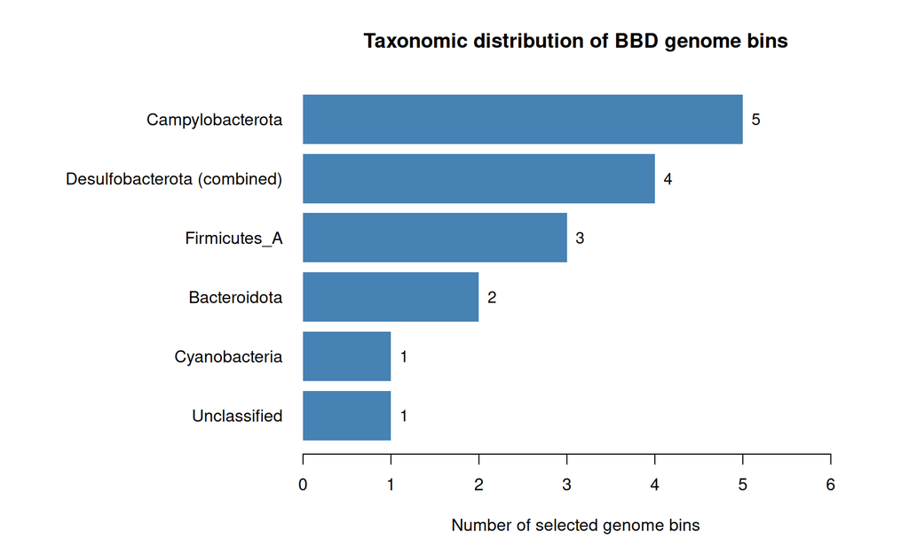

```r
# Use the taxonomy summary generated earlier
plot_data <- taxonomy_summary

# Combine related phylum groups for visualisation
plot_data$Phylum_group <- plot_data$Phylum

plot_data$Phylum_group[
  plot_data$Phylum_group %in%
    c("Desulfobacterota", "Desulfobacterota_I")
] <- "Desulfobacterota (combined)"

# Count genome bins in each phylum group
counts <- sort(
  table(plot_data$Phylum_group),
  decreasing = TRUE
)

# Set margins for long phylum names
op <- par(mar = c(5, 15, 4, 3))

# Create horizontal bar chart
positions <- barplot(
  rev(counts),
  horiz = TRUE,
  las = 1,
  xlim = c(0, max(counts) + 1.2),
  col = "steelblue",
  border = NA,
  xlab = "Number of selected genome bins",
  main = "Taxonomic distribution of BBD genome bins"
)

# Display counts beside each bar
text(
  x = rev(as.numeric(counts)) + 0.15,
  y = positions,
  labels = rev(as.numeric(counts)),
  cex = 0.95
)
```

```r
# Restore graphics settings
par(op)
```

#### 4.4.4 Resolution of taxonomic assignments

GTDB-Tk assignments showed different levels of detail in the taxonomic information.

The figure below shows how many of the 16 bins had an assignment at each level.

This is a **description of the GTDB-Tk output**, not a confirmation of the correctness of every assignment.

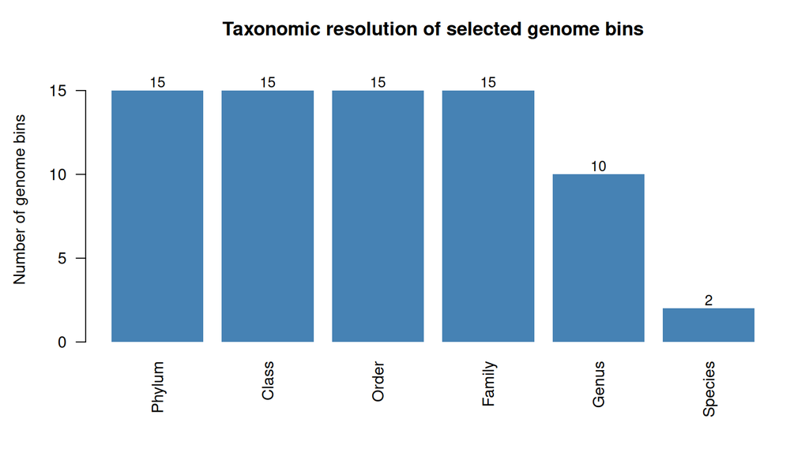

```r
# Define the taxonomic ranks
rank_columns <- c(
  "Phylum", "Class", "Order",
  "Family", "Genus", "Species"
)

# Count genomes with resolved assignments at each rank
resolved <- colSums(
  !is.na(taxonomy_summary[rank_columns]) &
  taxonomy_summary[rank_columns] != "Unclassified"
)

# Adjust margins for rank labels
op <- par(mar = c(7, 4.5, 3, 1.5))

# Create taxonomic resolution bar chart
positions <- barplot(
  resolved,
  col = "steelblue",
  border = NA,
  ylim = c(0, 17),
  ylab = "Number of genome bins",
  main = "Taxonomic resolution of selected genome bins",
  las = 2
)

# Add counts above the bars
text(
  x = positions,
  y = resolved + 0.5,
  labels = resolved,
  cex = 0.9
)
```

```r
# Restore original graphics settings
par(op)
```

#### 4.4.5 Recovery of a *Roseofilum*-classified genome

One of the most useful assignments was for `metabat.45`.

The `_A` part is part of the GTDB name. Has not been changed to a regular species name.

The exact assignment can be checked in the output:

```bash
awk -F '\t' '$1=="metabat.45" {print $2}' \

gtdbtk.bac120.summary.tsv
```

CheckM previously found `metabat.45` to have **97.56% completeness** and **0.67% contamination** making it a good candidate for more analysis.

The genus *Roseofilum* is connected to BBD mats but finding it here does not prove it is active, common or causes coral tissue damage.

#### 4.4.6 bacterial lineages

Several bins were placed in **Campylobacterota** including some in *Halarcobacter* *Poseidonibacter* and *Sulfurospirillum_A*.

Other bins were found in **Desulfobacterota**. *Desulfobacterota_I**, including one in *Maridesulfovibrio*.

These groups offer options for looking into sulfur or breathing-related ways of getting energy during later steps; their roles can’t be guessed just from their names.

Other bins were in **Firmicutes_A**. *Bacteroidota**.

The largest contig that was taken out separately `contig_134` was in Bacteroidota and in genus **UBA2561**.

CheckM found this bin to be **97.62%** and **1.64% contaminated**.

In contrast `metabat.70` was not classified at the phylum level showing that being in the GTDB-Tk results does not always mean there is a classification.

### 4.5 Discussion

#### 4.5.1 Taxonomic diversity in the selected genome set

The bins collected cover bacterial groups rather than just one type of bacteria.

This matches what is expected in a mat but the 16 bins are just a part of the genetic material that could be put together grouped and kept using the workshops completeness rule.

The way the bins are spread across phyla should not be seen as the way the cells or genetic material were spread in the sample.

#### 4.5.2 Potential implications for interactions

Finding a genome from *Roseofilum* along with bins from Campylobacterota and Desulfobacterota suggests looking more into the communitys possible ways of getting energy.

BBD mats might have differences in light, oxygen and other chemicals, which gives a reason to check for genes that are linked to different ways of getting energy.

However these classifications do not show energy exchange, physical connections or interactions between the found organisms.

Such ideas would need information from functions, how the organisms work or where they are.

#### 4.5.3 Taxonomy and functional potential are not the same

GTDB-Tk gives classifications based on genomes; it does not say what functions are present, complete, active or used.

Very similar organisms can have different genes and how they work.

The next steps look at predicted genes and energy processes making a difference between what the genome can do and what is actually happening.

#### 4.5.4. Uncertainty

**Genome completeness:** The than 15% rule kept many incomplete genomes. Missing parts of the genome can change how the classification is done and energy process studies.

**Reference representation:** GTDB-Tk classifications depend on reference genomes; some groups may not be clear.

**Database names:** GTDB uses genome-based names. Adds special parts. These are kept as they are, like `Firmicutes_A` `Desulfobacterota_I` and *Roseofilum reptotaenium_A*.

**Recovery bias:** The bins chosen do not show all the material in the original BBD community.

**Ecological interpretation:** Finding a genome does not show that the organism is alive how common it is, how active its genes are or if it causes disease.

### 4.6

GTDB-Tk gave classifications for all **16** genome bins from the BBD metagenomic assembly.

Fifteen of them got a classification at the phylum level covering bacterial groups while one did not get a classification at that level.

The finding of the complete `metabat.45` bin that is in *Roseofilum* is a good target for more study along with other groups that could be important for energy processes.

The next step uses **Prokka** to find genes and label functions setting up a base for later energy process studies.

Just having a classification is not proof of energy activity or being involved in BBD.

### 4.7 References

Chaumeil, P.-A., Mussig A. J., Hugenholtz, P., & Parks D. H. (2020). GTDB-Tk: A toolkit to classify genomes, with the Genome Taxonomy Database. *Bioinformatics, 36*(6) 1925–1927. Https://doi.org/10.1093/bioinformatics/btz848

Parks, D. H., Chuvochina, M., Waite, D. W., Rinke, C., Skarshewski, A., Chaumeil, P.-A. & Hugenholtz, P. (2018). A standardized bacterial taxonomy based on genome phylogeny substantially revises the tree of life. *Nature Biotechnology, 36* 996–1004. Https://doi.org/10.1038/nbt.4229

## Gene annotation

# 5. Functional Gene Annotation with Prokka

## 5.1

After we finished assembly, genome binning, quality assessment and taxonomic classification the next step in the black band disease (BBD) metagenomics workflow was to identify genes inside the recovered bacterial genome bins.

Gene annotation supplies information about predicted coding sequences and their possible biological functions. This gives a basis for exploring the metabolic potential of the microorganisms that appear in the assembly.

Prokka is a genome annotation tool that identifies genomic features predicts protein-coding sequences and assigns possible functions when enough sequence information exists.

In this analysis Prokka was applied to the 16 genome bins chosen from the BBD metagenome that comes from *Acropora hyacinthus* at Orpheus Island, Queensland, Australia.

The objectives were to:

1. Generate annotated gene and protein datasets for the 16 selected genome bins.
2. Compare the number of predicted coding sequences (CDS) among bins.
3. Examine the annotation composition of the *Roseofilum*-classified genome, `metabat.45`.
4. Prepare annotated sequences for metabolic pathway analysis.

## 5.2 Methods

### 5.2.1 Initial Prokka annotation

An initial annotation was carried out on `metabat.45` which had been classified by GTDB-Tk as *Roseofilum reptotaenium_A*.

The following commands were executed from the `prokka` directory.

```bash
cd ~/Beneath-the-band/prokka

bin=metabat.45

prokka --cpus 2 \

--outdir "$bin" \

--prefix "$bin" \

"../metabat/bins_bbd/${bin}.fa"
```

This test run finished successfully with Prokka version 1.14.6 and produced annotated sequence files and a table summarizing predicted genomic features.

### 5.2.2 Batch annotation using SLURM

After the initial test a SLURM script called `run_prokka.sh` was created to annotate the selected genome bins.

The script read the list of 16 selected genome identifiers from `checkm/bbd_topbins.txt`.

Each genome was annotated one by one. The output files were written to a folder named after the corresponding genome bin.

The script was submitted using:

```bash
sbatch run_prokka.sh
```

SLURM gave the job ID `512`.

The job later reached the `COMPLETED` state. Ran for 25 minutes and 6 seconds.

### 5.2.3 Output verification

The presence of annotation tables (`.tsv`) and predicted protein sequence files (`.faa`) was checked for all 16 genome bins.

```bash
while read bin; do

if [ -s "$bin/$bin.tsv" ] && \

[ -s "$bin/$bin.faa" ]; then

echo "COMPLETE: $bin"

echo "CHECK: $bin"

fi

done <../checkm/bbd_topbins.txt
```

All 16 selected bins passed this check.

The number of predicted protein-coding sequences was then counted from the Prokka annotation tables.

```bash
for file in */*.tsv; do

bin=$(basename "$file".tsv)

awk -F '\t' -v bin="$bin" \

'NR>1 && $2=="CDS" {n++}

END {print bin, n+0}' "$file"

done
```

The annotation tables contain feature types. Only the entries marked as `CDS` were counted when comparing predicted protein-coding sequences.

## 5.3 Results

### 5.3.1 Overview of predicted coding sequences

The number of predicted CDS differed across bins from **223** in `metabat.36` to **5,496**, in `metabat.45`.

The three bins that had the predicted coding repertoires were:

1. `Metabat.45`. 5,496 CDS
2. `Contig_134`. 3,913 CDS
3. `Metabat.60`. 2,178 CDS

To keep the results reproducible I read the annotation tables from the Prokka output directories.

### 5.3.2 Importing Prokka annotation data

```r
# Read the 16 genome bins selected after CheckM assessment.
bin_ids <- readLines(
  "checkm/bbd_topbins.txt",
  warn = FALSE
)

bin_ids <- trimws(bin_ids)
bin_ids <- bin_ids[nzchar(bin_ids)]

stopifnot(
  length(bin_ids) == 16,
  !anyDuplicated(bin_ids)
)

# Locate the corresponding Prokka annotation tables.
annotation_files <- file.path(
  "prokka",
  bin_ids,
  paste0(bin_ids, ".tsv")
)

missing_files <- annotation_files[
  !file.exists(annotation_files)
]

if (length(missing_files) > 0) {
  stop(
    "Missing Prokka annotation files:\n",
    paste(missing_files, collapse = "\n")
  )
}

# Import each annotation table and retain its genome ID.
read_annotation <- function(file, bin) {

  data <- read.delim(
    file,
    sep = "\t",
    header = TRUE,
    stringsAsFactors = FALSE,
    check.names = FALSE
  )

  required <- c("ftype", "product")

  missing_columns <- setdiff(
    required,
    names(data)
  )

  if (length(missing_columns) > 0) {
    stop(
      "Missing columns in ", file, ": ",
      paste(missing_columns, collapse = ", ")
    )
  }

  data$Genome <- bin

  return(data)
}

# Read all 16 annotation tables.
annotations <- Map(
  read_annotation,
  annotation_files,
  bin_ids
)

names(annotations) <- bin_ids

# Count protein-coding sequences (CDS) in each genome.
cds_counts <- vapply(
  annotations,
  function(data) {
    sum(
      trimws(data$ftype) == "CDS",
      na.rm = TRUE
    )
  },
  integer(1)
)

# Build a summary table.
cds_summary <- data.frame(
  Genome = names(cds_counts),
  Predicted_CDS = as.integer(cds_counts),
  stringsAsFactors = FALSE
)

# Sort genome bins from highest to lowest CDS count.
cds_summary <- cds_summary[
  order(
    cds_summary$Predicted_CDS,
    decreasing = TRUE
  ),
]

rownames(cds_summary) <- NULL

# Calculate the total directly from the annotation files.
total_cds <- sum(cds_summary$Predicted_CDS)

# Verify that all 16 genomes were processed.
stopifnot(
  nrow(cds_summary) == 16,
  all(cds_summary$Predicted_CDS >= 0)
)

# Display the calculated total.
cat("Genome bins analysed:", nrow(cds_summary), "\n")
```

```
## Genome bins analysed: 16
```

```r
cat("Total predicted CDS:", total_cds, "\n")
```

```
## Total predicted CDS: 19251
```

```r
# Display the results table.
knitr::kable(
  cds_summary,
  col.names = c(
    "Genome bin",
    "Predicted CDS"
  ),
  caption = paste0(
    "Predicted protein-coding sequences identified ",
    "by Prokka across the 16 selected BBD genome bins. ",
    "Total predicted CDS: ",
    format(total_cds, big.mark = ","),
    "."
  )
)
```

Predicted protein-coding sequences identified by Prokka across the 16 selected BBD genome bins. Total predicted CDS: 19,251.

| Genome bin | Predicted CDS |
| --- | --- |
| metabat.45 | 5496 |
| contig_134 | 3913 |
| metabat.60 | 2178 |
| metabat.71 | 1009 |
| metabat.18 | 949 |
| metabat.3 | 895 |
| metabat.9 | 731 |
| metabat.22 | 667 |
| metabat.37 | 634 |
| metabat.50 | 582 |
| metabat.56 | 494 |
| metabat.10 | 437 |
| metabat.76 | 417 |
| metabat.32 | 398 |
| metabat.70 | 228 |
| metabat.36 | 223 |

The table shows how many CDS features were found in each Prokka annotation file. These numbers are predictions of coding sequences, not measurements of gene expression or protein production.

### 5.3.3 Comparison of predicted CDS among genome bins

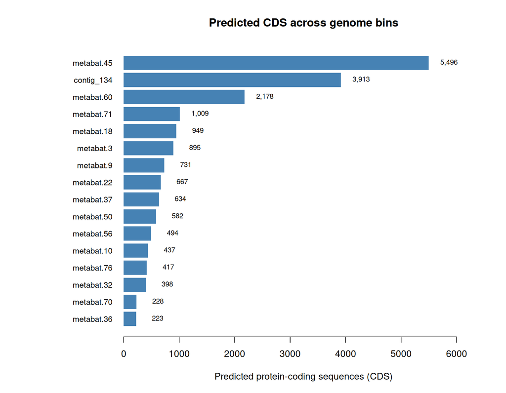

```r
# Sort genome bins by predicted CDS count
cds_plot <- cds_summary[
  order(cds_summary$Predicted_CDS, decreasing = TRUE),
]

# Set margins and preserve original settings
op <- par(mar = c(5, 11, 4, 2))

# Plot predicted CDS counts
bar_positions <- barplot(
  rev(cds_plot$Predicted_CDS),
  names.arg = rev(cds_plot$Genome),
  horiz = TRUE,
  las = 1,
  col = "steelblue",
  border = NA,
  xlim = c(0, max(cds_plot$Predicted_CDS) * 1.18),
  xlab = "Predicted protein-coding sequences (CDS)",
  main = "Predicted CDS across genome bins",
  cex.names = 0.85
)

# Add counts to the end of each bar
text(
  x = rev(cds_plot$Predicted_CDS) +
    max(cds_plot$Predicted_CDS) * 0.02,
  y = bar_positions,
  labels = format(
    rev(cds_plot$Predicted_CDS),
    big.mark = ","
  ),
  cex = 0.75,
  pos = 4
)
```

```r
# Restore graphics settings
par(op)
```

The distribution shows a large difference in predicted CDS counts across the selected genome bins.

`Metabat.45` had the number of predicted coding sequences followed by `contig_134` and then `metabat.60`.

These differences should be looked at together with genome completeness and the amount of sequence that was recovered. A larger CDS count alone does not prove that the organism is more active or more important in its environment.

### 5.3.4 Annotation of the Roseofilum-classified genome

The genome bin `metabat.45` was identified by GTDB-Tk as *Roseofilum reptotaenium_A*.

The earlier CheckM analysis estimated that **97.56% completeness** and **0.67% contamination**, for `metabat.45`.

Prokka identified a total of **5,496 predicted CDS** within the genome bin `metabat.45`.

The annotation table was examined to separate predicted proteins that received a product description from those that were labelled as proteins.

```r
# Retrieve the Roseofilum-associated genome bin
roseofilum <- annotations[["metabat.45"]]

# Select predicted coding sequences
roseofilum_cds <- roseofilum[
  !is.na(roseofilum$ftype) &
    roseofilum$ftype == "CDS",
  ,
  drop = FALSE
]

# Extract predicted protein descriptions
products <- trimws(roseofilum_cds$product)
products[is.na(products)] <- ""

# Count annotation categories
hypothetical <- sum(
  products == "hypothetical protein"
)

other_products <- sum(
  products != "" &
    products != "hypothetical protein"
)

unlabelled <- sum(products == "")

# Create annotation summary
annotation_summary <- data.frame(
  Category = c(
    "Hypothetical proteins",
    "Other predicted products",
    "No product description"
  ),
  CDS = c(
    hypothetical,
    other_products,
    unlabelled
  )
)

# Calculate percentages
annotation_summary$Percentage <- round(
  100 * annotation_summary$CDS /
    sum(annotation_summary$CDS),
  1
)

# Validate observed results
stopifnot(
  nrow(roseofilum_cds) == 5496,
  hypothetical == 3329,
  other_products == 2167,
  unlabelled == 0
)

# Display summary table
knitr::kable(
  annotation_summary,
  caption = paste(
    "Annotation composition of the",
    "Roseofilum-classified genome bin metabat.45."
  )
)
```

Annotation composition of the Roseofilum-classified genome bin metabat.45.

| Category | CDS | Percentage |
| --- | --- | --- |
| Hypothetical proteins | 3329 | 60.6 |
| Other predicted products | 2167 | 39.4 |
| No product description | 0 | 0.0 |

Among the 5,496 predicted CDS:

- **3,329 (60.6%)** were annotated as proteins.
- **2,167 (39.4%)** received predicted product descriptions.

The high proportion of proteins shows that many predicted coding sequences could not be assigned more specific product descriptions through this annotation workflow.

### 5.3.5 Visualisation of annotation composition

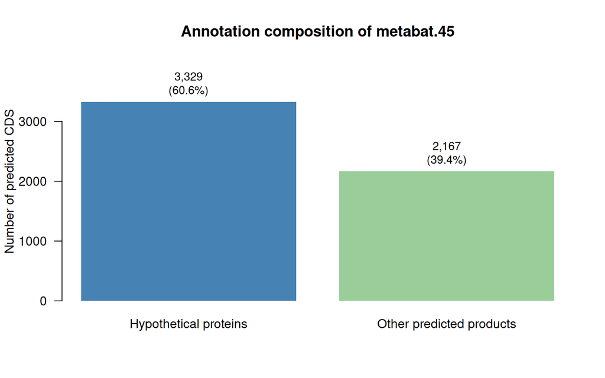

```r
# Prepare annotation categories
plot_data <- annotation_summary[
  annotation_summary$CDS > 0,
  ,
  drop = FALSE
]

bar_values <- plot_data$CDS
names(bar_values) <- plot_data$Category

# Create the bar chart
bar_positions <- barplot(
  bar_values,
  col = c("steelblue", "darkseagreen3"),
  border = NA,
  ylim = c(0, max(bar_values) * 1.2),
  ylab = "Number of predicted CDS",
  main = "Annotation composition of metabat.45",
  las = 1
)

# Add counts and percentages above bars
text(
  x = bar_positions,
  y = bar_values,
  labels = paste0(
    format(bar_values, big.mark = ","),
    "\n(",
    plot_data$Percentage,
    "%)"
  ),
  pos = 3,
  cex = 0.9
)
```

Most predicted coding sequences in `metabat.45` were labelled as hypothetical proteins yet the remaining 2,167 predicted CDS provide product descriptions that can be examined during downstream functional analysis.

### 5.3.6 Distribution of predicted CDS counts

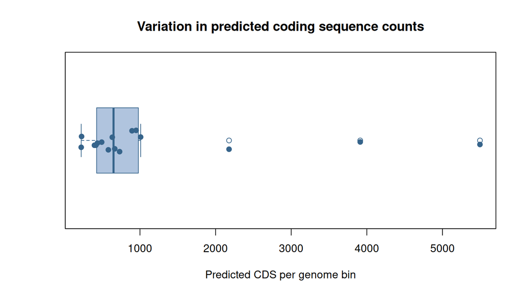

```r
par(mar = c(5, 5, 4, 2))

boxplot(
  cds_summary$Predicted_CDS,
  horizontal = TRUE,
  col = "lightsteelblue",
  border = "steelblue4",
  xlab = "Predicted CDS per genome bin",
  main = "Variation in predicted coding sequence counts"
)

stripchart(
  cds_summary$Predicted_CDS,
  method = "jitter",
  jitter = 0.08,
  pch = 19,
  col = "steelblue4",
  add = TRUE
)
```

**Figure 3.** The distribution illustrates variation in recovered coding sequence counts across selected genome bins highlighting differences in genome assembly and completeness.

Because the bins differ in estimated completeness and recovered genomic content these counts should not be treated as comparable measures of organismal functional complexity.

## 5.4 Discussion

Prokka successfully generated annotation datasets for all 16 selected genome bins.

### 5.4.1 Differences among genome bins

The number of predicted CDS differed substantially across selected bins.

Such variation may reflect differences in genome size, completeness and gene content.

The completeness threshold used during bin selection was, than 15% meaning that some retained bins were substantially incomplete.

Consequently low CDS counts may reflect genome recovery rather than a genuinely small coding repertoire.

Likewise high CDS counts should not automatically be interpreted as evidence of metabolic complexity.

### 5.4.2 Functional annotation of metabat.45

The genome was particularly informative because it combined high estimated completeness with the largest predicted CDS count in the selected dataset.

Its classification as *Roseofilum reptotaenium_A* also makes it relevant to investigation of the BBD-associated microbial community.

However 60.6% of its predicted CDS were annotated as proteins.

This highlights the limitations of assigning functions from sequence comparisons alone.

The 2,167 CDS with predicted product descriptions provide a starting point for identifying candidate metabolic functions.

### 5.4.3 Interpretation of predicted functions

Prokka annotations are predictions.

A predicted coding sequence does not necessarily indicate that the corresponding gene is expressed, that a functional protein is produced or that a particular metabolic process is active.

Likewise the presence of a predicted gene does not establish a contribution to coral disease.

Further analysis is therefore required to investigate which metabolic pathways may be represented within the genome bins.

### 5.4.4 Connection to metabolic pathway reconstruction

The Prokka output files provide the annotated sequences needed for the stage of the workflow.

Metabolic pathway analysis will investigate the potential suggested by these predicted genes.

Particular attention can be given to pathways to microbial metabolism and biogeochemical processes while distinguishing predicted genomic potential from experimentally demonstrated activity.

## 5.5

Prokka generated gene annotation outputs for all 16 selected BBD genome bins.

The largest number of predicted CDS occurred in metabat.45 with 5,496 sequences, followed by contig_134 with 3,913 and metabat.60 with 2,178.

Within metabat.45 3,329 CDS were annotated as proteins while 2,167 received other predicted product descriptions.

These findings demonstrate the extent of predicted coding information recovered from the selected genome bins and provide a foundation, for metabolic pathway reconstruction.

## 5.6 Reference

Seemann, T. (2014). Prokka: prokaryotic genome annotation. *Bioinformatics* 30(14) 2068–2069. Https://doi.org/10.1093/bioinformatics/btu153

## Metabolic pathways

# 6. Reconstruction of Metabolic Pathways with MinPath

## 6.1

The earlier parts of this project reconstructed genome bins from a black band disease (BBD) metagenome checked their quality using CheckM classified them using GTDB-Tk and annotated predicted genes using Prokka.

The next step was to look into the metabolic pathways that the annotated genomes might have.

MinPath (Minimal Pathways) takes an approach to find a set of pathways from enzyme annotations. Of assuming that every pathway connected to an enzyme is present it tries to find a smaller set of pathways that can explain the enzyme information found.

This study used the Prokka annotation results from the 16 chosen genome bins.

The goals were to:

1. Look at the pathway predictions from the annotated genomes.
2. Compare some pathway evidence among the recovered bins.
3. Find out the limits of understanding partially supported pathways.

This analysis is about what the genes suggest the microbes can do, not about what they do in the environment.

## 6.2 Methods

### 6.2.1 Data used

The analysis followed the Prokka annotation step.

Prokka gave annotated gene and protein information for all 16 selected genome bins. These outputs were the starting point for the pathway reconstruction.

The genome identifiers were kept in:

`checkm/bbd_topbins.txt`

The MinPath analysis was done inside the `Beneath-the-band` project.

### 6.2.2 MinPath process

MinPath was used to look at pathway evidence from the annotated genomes.

The process was first run on the selected bins. In the attempt only seven pathway reports were made because processing stopped at `metabat.56`.

The process was run again to finish the rest of the analysis.

The final results were checked to make sure pathway reports were available for all 16 genome bins.

The interpretation below is based on these reports.

### 6.2.3 Pathway evidence

Two things were looked at in the MinPath results:

- **Enzyme-family evidence:** How many enzyme families were found compared to those linked to a pathway.
- **MinPath selection:** Whether the pathway was included in the pathway solution.

A pathway with `minpath = 1` was seen as selected by MinPath.

A pathway with `minpath = 0` was not considered a pathway even if some enzyme families were found.

These values were looked at together not separately.

## 6.3 Results

### 6.3.1 Completion of pathway analysis

The first run made seven reports before stopping.

After rerunning all 16 genome bins had pathway reports available.

This made it possible to compare pathway predictions across the genome set.

### 6.3.2 Evidence for PWY-101

PWY-101 was found in the pathway results for four genome bins:

In these results `metabat.32` and `metabat.45` had a MinPath selection value of `1`.

For `metabat.45` the report also showed four out of four enzyme families.

These findings give support for PWY-101 in `metabat.45` but the pathway prediction does not prove that the pathway was active in the microbial mat.

The data does not support saying all four genome bins have the pathway support.

### 6.3.3 Evidence for PWY-5360

PWY-5360 was only found in the results for `metabat.18`.

The report said:

- One of three enzyme families was found.
- MinPath selection value was `0`.

So PWY-5360 was not in the pathway solution for this genome.

Finding one enzyme family is not enough to say the pathway is complete.

This shows that just finding an enzyme does not always mean the full pathway is there.

### 6.3.4 Comparison of pathway evidence

The table below shows the findings from the MinPath reports.

```r
# Compile selected observations from MinPath reports
pathway_evidence <- data.frame(
  Pathway = c(
    "PWY-101",
    "PWY-101",
    "PWY-101",
    "PWY-101",
    "PWY-5360"
  ),
  Genome = c(
    "contig_134",
    "metabat.32",
    "metabat.45",
    "metabat.50",
    "metabat.18"
  ),
  Enzyme_evidence = c(
    "Not recorded here",
    "Not recorded here",
    "4/4",
    "Not recorded here",
    "1/3"
  ),
  MinPath_selection = c(
    "Not recorded here",
    "1",
    "1",
    "Not recorded here",
    "0"
  ),
  stringsAsFactors = FALSE
)

# Display the pathway evidence table
knitr::kable(
  pathway_evidence,
  col.names = c(
    "Pathway",
    "Genome bin",
    "Enzyme-family evidence",
    "MinPath selection"
  ),
  caption = paste(
    "Selected pathway observations from",
    "the completed MinPath analysis."
  )
)
```

Selected pathway observations from the completed MinPath analysis.

| Pathway | Genome bin | Enzyme-family evidence | MinPath selection |
| --- | --- | --- | --- |
| PWY-101 | contig_134 | Not recorded here | Not recorded here |
| PWY-101 | metabat.32 | Not recorded here | 1 |
| PWY-101 | metabat.45 | 4/4 | 1 |
| PWY-101 | metabat.50 | Not recorded here | Not recorded here |
| PWY-5360 | metabat.18 | 1/3 | 0 |

The entries marked “Not recorded here” mean those values were not in the summary. They should not be seen as zero or missing from the reports.

### 6.3.5 Visual comparison of enzyme evidence

The enzyme-family counts available can be compared between `metabat.45` for PWY-101 and `metabat.18` for PWY-5360.

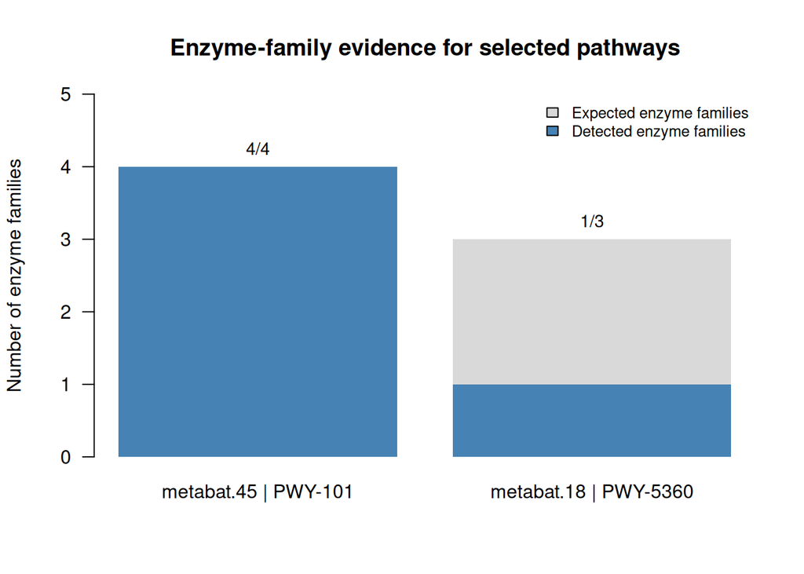

```r
enzyme_data <- data.frame(
  Genome = c("metabat.45", "metabat.18"),
  Pathway = c("PWY-101", "PWY-5360"),
  Detected = c(4, 1),
  Expected = c(4, 3)
)

labels <- paste(
  enzyme_data$Genome,
  enzyme_data$Pathway,
  sep = " | "
)

positions <- barplot(
  enzyme_data$Expected,
  names.arg = labels,
  col = "grey85",
  border = NA,
  ylim = c(0, 5),
  ylab = "Number of enzyme families",
  main = "Enzyme-family evidence for selected pathways",
  las = 1
)

barplot(
  enzyme_data$Detected,
  add = TRUE,
  col = "steelblue",
  border = NA,
  axes = FALSE
)

text(
  positions,
  enzyme_data$Expected + 0.25,
  labels = paste0(
  enzyme_data$Detected,
  "/",
  enzyme_data$Expected
),

cex = 0.9
)

legend(
  "topright",
  legend = c(
  "Expected enzyme families",
  "Detected enzyme families"
),

fill = c("grey85", "steelblue"),
  bty = "n",
  cex = 0.8
)
```

**Figure 1.** Comparison of found and expected enzyme families for two pathway–genome combinations. PWY-101 in `metabat.45` had 4/4 enzyme families. Was chosen by MinPath while PWY-5360 in `metabat.18` had 1/3 enzyme families and was not chosen. These are examples, not a summary of all predicted pathways.

## 6.4 Discussion

### 6.4.1 Interpreting MinPath predictions

MinPath offers a way to understand enzyme annotations in terms of metabolic pathways.

Its simple way helps to reduce the number of pathways that are guessed from enzyme matches that might be in pathways.

However the results depend on how complete and accurate the gene annotationsre

A pathway that MinPath picks should be seen as a supported prediction not as proof of what’s actually happening.

### 6.4.2 PWY-101 in genomes

PWY-101 was found in four genome bins.

MinPath chose PWY-101 for `metabat.32` and `metabat.45` which means it was in the pathway solutions for those genomes.

The 4/4 enzyme evidence for `metabat.45` adds more support to this.

These results do not prove that the pathway was active in the BBD microbial mat.

### 6.4.3 Incomplete evidence for PWY-5360

PWY-5360 is a case.

Even though one enzyme family connected to it was found in `metabat.18` one of three expected families was there and MinPath did not choose the pathway.

This shows the need to tell the difference between one enzyme and a full pathway.

Calling PWY-5360 a confirmed pathway would be wrong.

### 6.4.4 Link to classification

Earlier the GTDB-Tk analysis found several bacterial groups among the genomes including a *Roseofilum*-classified one in `metabat.45`.

MinPath results add another layer by looking at the functions of the genes.

Taxonomy and pathway prediction are different.

Taxonomy tells about how different speciesre related while pathway prediction looks at what they can do.

Neither one alone shows what the microbes are doing together in the BBD mat.

### 6.4.5 Limitations

Several things affect how the results are seen.

**Genome completeness:** Some of the 16 genome bins were not complete. Missing parts could mean missing enzyme evidence.

**Annotation issues:** Prokka gives gene functions based on sequence. Wrong or unclear annotations can affect what pathways are found.

**Enzymes in pathways:** Some enzymes are in than one pathway. Finding an enzyme doesn’t mean it’s in a pathway.

**Computational choices:** MinPath finds a set of pathways. A pathway that is chosen is not the same, as proof that it is working.

** activity:** Genome-based analyses cannot directly show gene expression, metabolic rates or how organisms interact with each other.

These limits need to be kept in mind when looking at pathway results in the setting of black band disease.

## 6.5

MinPath analysis was done for all 16 genome bins that were chosen from the BBD metagenome.

The findings showed differences in pathway evidence between the genomes that were found.

PWY-101 appeared in four genome-bin reports with MinPath choosing the pathway in `metabat.32` and `metabat.45`. The second one had all four enzyme families linked to the pathway.

On the hand PWY-5360 appeared only in `metabat.18` where one out of three enzyme families was found and MinPath did not choose the pathway.

These examples show how important it is to check enzyme evidence and pathway selection before making conclusions.

The pathway predictions build on the genome annotation work and offer a way to look into the possible metabolic abilities of the microbial community linked to black band disease.

They do not by themselves prove metabolic activity. Show that they cause coral disease.

## 6.6 References

Ye, Y., & Doak T. G. (2009). A parsimony approach to biological pathway reconstruction/inference, for genomes and metagenomes. *PLoS Computational Biology, 5*(8) e1000465. Https://doi.org/10.1371/journal.pcbi.1000465

Seemann, T. (2014). Prokka: prokaryotic genome annotation. *Bioinformatics, 30*(14) 2068–2069. Https://doi.org/10.1093/bioinformatics/btu153

# References

Carlton, R. G., & Richardson, L. L. (1995). Oxygen and sulfide dynamics in a horizontally migrating cyanobacterial mat: Black band disease of corals. *FEMS Microbiology Ecology, 18*(2), 155–162. https://doi.org/10.1111/j.1574-6941.1995.tb00173.x

Glas, M. S., Sato, Y., Ulstrup, K. E., & Bourne, D. G. (2012). Biogeochemical conditions determine virulence of black band disease in corals. *The ISME Journal, 6*, 1526–1534. https://doi.org/10.1038/ismej.2012.2

Sato, Y., Ling, E. Y. S., Turaev, D., Laffy, P., Weynberg, K. D., Rattei, T., Willis, B. L., & Bourne, D. G. (2017). Unraveling the microbial processes of black band disease in corals through integrated genomics. *Scientific Reports, 7*, Article 40455. https://doi.org/10.1038/srep40455

Zimmer, B. L., May, A. L., Bhedi, C. D., Dearth, S. P., Prevatte, C. W., Pratte, Z., Campagna, S. R., & Richardson, L. L. (2014). Quorum sensing signal production and microbial interactions in a polymicrobial disease of corals and the coral surface mucopolysaccharide layer. *PLOS ONE, 9*(9), e108541. https://doi.org/10.1371/journal.pone.0108541